# Project: Exploring TMDB Dataset for year-over-year patterns for movie genres

### Looking for patterns on:

- #movie releases have changed over years by genre
- Popularity of genres have changed over years
- Budget, Revenue and Profit have changed over years

1. Introduction  
2. Data Wrangling  
3. Exploratory Data Analysis  
4. Conclusions

## 1. Introduction

```python
import pandas as pd
import numpy as np
import matplotlib.pyplot as plt
import seaborn as sns

%matplotlib inline
```

## 2. Data Wrangling

### General Properties

```python
df = pd.read_csv('tmdb-movies.csv')
df.head(2)
```

|  | id | imdb_id | popularity | budget | revenue | original_title | cast | homepage | director | tagline | ... | overview | runtime | genres | production_companies | release_date | vote_count | vote_average | release_year | budget_adj | revenue_adj |
| --- | --- | --- | --- | --- | --- | --- | --- | --- | --- | --- | --- | --- | --- | --- | --- | --- | --- | --- | --- | --- | --- |
| 0 | 135397 | tt0369610 | 32.985763 | 150000000 | 1513528810 | Jurassic World | Chris Pratt\|Bryce Dallas Howard\|Irrfan Khan\|Vi... | http://www.jurassicworld.com/ | Colin Trevorrow | The park is open. | ... | Twenty-two years after the events of Jurassic ... | 124 | Action\|Adventure\|Science Fiction\|Thriller | Universal Studios\|Amblin Entertainment\|Legenda... | 6/9/15 | 5562 | 6.5 | 2015 | 1.379999e+08 | 1.392446e+09 |
| 1 | 76341 | tt1392190 | 28.419936 | 150000000 | 378436354 | Mad Max: Fury Road | Tom Hardy\|Charlize Theron\|Hugh Keays-Byrne\|Nic... | http://www.madmaxmovie.com/ | George Miller | What a Lovely Day. | ... | An apocalyptic story set in the furthest reach... | 120 | Action\|Adventure\|Science Fiction\|Thriller | Village Roadshow Pictures\|Kennedy Miller Produ... | 5/13/15 | 6185 | 7.1 | 2015 | 1.379999e+08 | 3.481613e+08 |

2 rows × 21 columns

```python
df.info()
```

```
<class 'pandas.core.frame.DataFrame'>
RangeIndex: 10866 entries, 0 to 10865
Data columns (total 21 columns):
id                      10866 non-null int64
imdb_id                 10856 non-null object
popularity              10866 non-null float64
budget                  10866 non-null int64
revenue                 10866 non-null int64
original_title          10866 non-null object
cast                    10790 non-null object
homepage                2936 non-null object
director                10822 non-null object
tagline                 8042 non-null object
keywords                9373 non-null object
overview                10862 non-null object
runtime                 10866 non-null int64
genres                  10843 non-null object
production_companies    9836 non-null object
release_date            10866 non-null object
vote_count              10866 non-null int64
vote_average            10866 non-null float64
release_year            10866 non-null int64
budget_adj              10866 non-null float64
revenue_adj             10866 non-null float64
dtypes: float64(4), int64(6), object(11)
memory usage: 1.7+ MB
```

#### Release Date should be a `datetime` vairable

```python
df = pd.read_csv('tmdb-movies.csv', parse_dates=['release_date'])
df.head(2)
```

|  | id | imdb_id | popularity | budget | revenue | original_title | cast | homepage | director | tagline | ... | overview | runtime | genres | production_companies | release_date | vote_count | vote_average | release_year | budget_adj | revenue_adj |
| --- | --- | --- | --- | --- | --- | --- | --- | --- | --- | --- | --- | --- | --- | --- | --- | --- | --- | --- | --- | --- | --- |
| 0 | 135397 | tt0369610 | 32.985763 | 150000000 | 1513528810 | Jurassic World | Chris Pratt\|Bryce Dallas Howard\|Irrfan Khan\|Vi... | http://www.jurassicworld.com/ | Colin Trevorrow | The park is open. | ... | Twenty-two years after the events of Jurassic ... | 124 | Action\|Adventure\|Science Fiction\|Thriller | Universal Studios\|Amblin Entertainment\|Legenda... | 2015-06-09 | 5562 | 6.5 | 2015 | 1.379999e+08 | 1.392446e+09 |
| 1 | 76341 | tt1392190 | 28.419936 | 150000000 | 378436354 | Mad Max: Fury Road | Tom Hardy\|Charlize Theron\|Hugh Keays-Byrne\|Nic... | http://www.madmaxmovie.com/ | George Miller | What a Lovely Day. | ... | An apocalyptic story set in the furthest reach... | 120 | Action\|Adventure\|Science Fiction\|Thriller | Village Roadshow Pictures\|Kennedy Miller Produ... | 2015-05-13 | 6185 | 7.1 | 2015 | 1.379999e+08 | 3.481613e+08 |

2 rows × 21 columns

```python
df.info()
```

```
<class 'pandas.core.frame.DataFrame'>
RangeIndex: 10866 entries, 0 to 10865
Data columns (total 21 columns):
id                      10866 non-null int64
imdb_id                 10856 non-null object
popularity              10866 non-null float64
budget                  10866 non-null int64
revenue                 10866 non-null int64
original_title          10866 non-null object
cast                    10790 non-null object
homepage                2936 non-null object
director                10822 non-null object
tagline                 8042 non-null object
keywords                9373 non-null object
overview                10862 non-null object
runtime                 10866 non-null int64
genres                  10843 non-null object
production_companies    9836 non-null object
release_date            10866 non-null datetime64[ns]
vote_count              10866 non-null int64
vote_average            10866 non-null float64
release_year            10866 non-null int64
budget_adj              10866 non-null float64
revenue_adj             10866 non-null float64
dtypes: datetime64[ns](1), float64(4), int64(6), object(10)
memory usage: 1.7+ MB
```

```python
df.describe()
```

|  | id | popularity | budget | revenue | runtime | vote_count | vote_average | release_year | budget_adj | revenue_adj |
| --- | --- | --- | --- | --- | --- | --- | --- | --- | --- | --- |
| count | 10866.000000 | 10866.000000 | 1.086600e+04 | 1.086600e+04 | 10866.000000 | 10866.000000 | 10866.000000 | 10866.000000 | 1.086600e+04 | 1.086600e+04 |
| mean | 66064.177434 | 0.646441 | 1.462570e+07 | 3.982332e+07 | 102.070863 | 217.389748 | 5.974922 | 2001.322658 | 1.755104e+07 | 5.136436e+07 |
| std | 92130.136561 | 1.000185 | 3.091321e+07 | 1.170035e+08 | 31.381405 | 575.619058 | 0.935142 | 12.812941 | 3.430616e+07 | 1.446325e+08 |
| min | 5.000000 | 0.000065 | 0.000000e+00 | 0.000000e+00 | 0.000000 | 10.000000 | 1.500000 | 1960.000000 | 0.000000e+00 | 0.000000e+00 |
| 25% | 10596.250000 | 0.207583 | 0.000000e+00 | 0.000000e+00 | 90.000000 | 17.000000 | 5.400000 | 1995.000000 | 0.000000e+00 | 0.000000e+00 |
| 50% | 20669.000000 | 0.383856 | 0.000000e+00 | 0.000000e+00 | 99.000000 | 38.000000 | 6.000000 | 2006.000000 | 0.000000e+00 | 0.000000e+00 |
| 75% | 75610.000000 | 0.713817 | 1.500000e+07 | 2.400000e+07 | 111.000000 | 145.750000 | 6.600000 | 2011.000000 | 2.085325e+07 | 3.369710e+07 |
| max | 417859.000000 | 32.985763 | 4.250000e+08 | 2.781506e+09 | 900.000000 | 9767.000000 | 9.200000 | 2015.000000 | 4.250000e+08 | 2.827124e+09 |

#### Observations:

1. Budget and Revenue is 0 for upto 50% records and so is Budget_adj and Revenue_adj
2. Min Runtime is 0
3. Max Runtime looks quite a long for a movie

### 2.1 Runtime = 0

```python
# Runtime of 0 (Looks like data entry error)

df[df['runtime']==0]
```

|  | id | imdb_id | popularity | budget | revenue | original_title | cast | homepage | director | tagline | ... | overview | runtime | genres | production_companies | release_date | vote_count | vote_average | release_year | budget_adj | revenue_adj |
| --- | --- | --- | --- | --- | --- | --- | --- | --- | --- | --- | --- | --- | --- | --- | --- | --- | --- | --- | --- | --- | --- |
| 92 | 370687 | tt3608646 | 1.876037 | 0 | 0 | Mythica: The Necromancer | Melanie Stone\|Adam Johnson\|Kevin Sorbo\|Nicola ... | http://www.mythicamovie.com/#!blank/y9ake | A. Todd Smith | NaN | ... | Mallister takes Thane prisoner and forces Mare... | 0 | Fantasy\|Action\|Adventure | Arrowstorm Entertainment\|Camera 40 Productions... | 2015-12-19 | 11 | 5.4 | 2015 | 0.000000e+00 | 0.0 |
| 334 | 361931 | tt5065822 | 0.357654 | 0 | 0 | Ronaldo | Cristiano Ronaldo | http://www.ronaldothefilm.com | Anthony Wonke | Astonishing. Intimate. Definitive. | ... | Filmed over 14 months with unprecedented acces... | 0 | Documentary | On The Corner Films\|We Came, We Saw, We Conque... | 2015-11-09 | 80 | 6.5 | 2015 | 0.000000e+00 | 0.0 |
| 410 | 339342 | tt2948712 | 0.097514 | 0 | 0 | Anarchy Parlor | Robert LaSardo\|Jordan James Smith\|Sara Fabel\|T... | NaN | Kenny Gage\|Devon Downs | NaN | ... | Six young college hopefuls vacationing and par... | 0 | Horror | NaN | 2015-01-01 | 15 | 5.6 | 2015 | 0.000000e+00 | 0.0 |
| 445 | 353345 | tt3800796 | 0.218528 | 0 | 0 | The Exorcism of Molly Hartley | Sarah Lind\|Devon Sawa\|Gina Holden\|Peter MacNei... | NaN | Steven R. Monroe | NaN | ... | Taking place years after The Haunting of Molly... | 0 | Horror | WT Canada Productions | 2015-10-09 | 52 | 5.0 | 2015 | 0.000000e+00 | 0.0 |
| 486 | 333653 | tt4058368 | 0.176744 | 0 | 0 | If There Be Thorns | Heather Graham\|Jason Lewis\|Rachael Carpani\|Mas... | NaN | Nancy Savoca | NaN | ... | The third installment in V.C. Andrews’ bests... | 0 | TV Movie\|Drama | A+E Studios\|Jane Startz Productions | 2015-04-05 | 11 | 5.4 | 2015 | 0.000000e+00 | 0.0 |
| 595 | 341051 | tt2914740 | 0.028725 | 0 | 0 | Deep Dark | Sean McGrath\|Denise Poirier\|Anne Sorce\|Tabor H... | http://deepdarkmovie.com | Michael Medaglia | NaN | ... | Fantasy - A failed sculptor discovers a strang... | 0 | Horror | NaN | 2015-01-01 | 11 | 4.6 | 2015 | 0.000000e+00 | 0.0 |
| 616 | 325843 | tt4333210 | 0.026797 | 0 | 0 | The Outfield | Cameron Dallas\|Hamilton Nash Grier\|Olivia Stuc... | NaN | Michael Goldfine | NaN | ... | The film follows a trio of varsity baseball pl... | 0 | Drama\|Comedy | NaN | 2015-11-10 | 20 | 6.6 | 2015 | 0.000000e+00 | 0.0 |
| 1241 | 296370 | tt3024964 | 0.135376 | 0 | 0 | Dance-Off | Kathryn McCormick\|Shane Harper\|Finola Hughes\|C... | NaN | NaN | NaN | ... | DANCE-OFF is a tongue-in-cheek family comedy s... | 0 | Romance\|Music\|Comedy | NaN | 2014-01-01 | 18 | 5.7 | 2014 | 0.000000e+00 | 0.0 |
| 1289 | 286372 | tt1791681 | 0.037459 | 3250000 | 0 | Treehouse | J. Michael Trautmann\|Dana Melanie\|Daniel Fredr... | http://www.imdb.com/title/tt1791681/ | Michael G. Bartlett | No kids allowed | ... | A teenage boy discovers the perpetrators of se... | 0 | Thriller\|Horror\|Mystery | Tiberius Film | 2014-10-20 | 16 | 3.4 | 2014 | 2.993546e+06 | 0.0 |
| 1293 | 286256 | tt3134058 | 0.036904 | 0 | 0 | Tim Maia | Robson Nunes\|Babú Santana\|Alinne Moraes\|Cauã... | NaN | Mauro Lima | Original language PORTUGUESE | ... | Biopic of Brazilian singer Tim Maia, from his ... | 0 | Documentary\|Drama\|Music | Globo Filmes | 2014-10-30 | 14 | 6.0 | 2014 | 0.000000e+00 | 0.0 |
| 1849 | 18247 | tt1212986 | 0.120350 | 0 | 0 | Spectacular! | Nolan Gerard Funk\|Jesse Moss\|Britt Irvin\|Tammi... | NaN | Robert Iscove | NaN | ... | A high school choir is fading in popularity, a... | 0 | Drama\|Music | NaN | 2009-02-16 | 13 | 5.2 | 2009 | 0.000000e+00 | 0.0 |
| 2315 | 48373 | tt1274296 | 0.171615 | 0 | 0 | Listen to Your Heart | Alexia Rasmussen\|Kent Moran\|Cybill Shepherd\|Sh... | http://www.listentoyourheartfilm.com/ | NaN | One song can change your life. | ... | Danny Foster doesn't have much: an apartment a... | 0 | Drama\|Music\|Romance | NaN | 2010-08-14 | 29 | 7.3 | 2010 | 0.000000e+00 | 0.0 |
| 2370 | 127717 | tt1525359 | 0.081892 | 0 | 0 | Freshman Father | Britt Irvin\|Merrilyn Gann\|Barbara Tyson\|Anthon... | NaN | Michael Scott | NaN | ... | NaN | 0 | NaN | NaN | 2010-06-05 | 12 | 5.8 | 2010 | 0.000000e+00 | 0.0 |
| 3329 | 20414 | tt1077026 | 0.082898 | 0 | 0 | Grande, grosso e Verdone | Carlo Verdone\|Claudia Gerini\|Eva Riccobono\|Vit... | NaN | Carlo Verdone | NaN | ... | No overview found. | 0 | Family | Filmauro | 2008-03-07 | 35 | 5.3 | 2008 | 0.000000e+00 | 0.0 |
| 3794 | 58253 | tt1588335 | 0.183134 | 0 | 0 | Toi, moi, les autres | Leïla Bekhti\|Benjamin Siksou\|Cécile Cassel\|C... | http://www.google.fr/m/url?ei=e3BxTcjeLMqB8wP6... | Audrey Estrougo | NaN | ... | NaN | 0 | Music\|Romance | NaN | 2011-02-22 | 17 | 5.2 | 2011 | 0.000000e+00 | 0.0 |
| 3857 | 289097 | tt1288636 | 0.095583 | 0 | 0 | Cell 213 | Bruce Greenwood\|Eric Balfour\|Michael Rooker\|De... | NaN | Stephen Kay | NaN | ... | Cocky young attorney Michael Gray finds himsel... | 0 | Horror | Access Motion Pictures | 2011-06-10 | 13 | 5.2 | 2011 | 0.000000e+00 | 0.0 |
| 3884 | 105885 | tt1754944 | 0.045198 | 0 | 0 | eCupid | Houston Rhines\|Andy Anderson\|John Callahan\|Gal... | NaN | J.C. Calciano | NaN | ... | From the director of Is It Just Me? comes this... | 0 | Romance | NaN | 2011-06-23 | 12 | 4.6 | 2011 | 0.000000e+00 | 0.0 |
| 4063 | 28004 | tt0359639 | 0.371510 | 6000000 | 0 | Madea's Family Reunion | Tyler Perry\|Blair Underwood\|Lynn Whitfield\|Bor... | NaN | Tyler Perry | NaN | ... | Just as the southern matriarch, Madea buries h... | 0 | Comedy | NaN | 2002-01-25 | 49 | 5.9 | 2002 | 7.273568e+06 | 0.0 |
| 4138 | 44266 | tt0242953 | 0.035895 | 0 | 0 | A Time for Dancing | Larisa Oleynik\|Shiri Appleby\|Peter Coyote\|Patr... | NaN | Peter Gilbert | NaN | ... | Their love of dance, and their friendship, is ... | 0 | Drama\|Music | NaN | 2002-09-06 | 14 | 7.5 | 2002 | 0.000000e+00 | 0.0 |
| 4829 | 110490 | tt1910605 | 0.140016 | 0 | 0 | Rags | Keke Palmer\|Avan Jogia\|Drake Bell\|Burkely Duff... | NaN | Bille Woodruff | NaN | ... | Rags follows the story of Charlie Prince, an o... | 0 | TV Movie\|Comedy\|Drama | NaN | 2012-05-28 | 24 | 5.7 | 2012 | 0.000000e+00 | 0.0 |
| 4944 | 158150 | tt2395247 | 0.026459 | 0 | 0 | How to Fall in Love | Brooke D'Orsay\|Eric Mabius\|Jody Thompson\|Gina ... | NaN | Mark Griffiths | NaN | ... | An accountant, who never quite grew out of his... | 0 | Comedy\|Romance\|TV Movie | Annuit Coeptis Entertainment Inc.\|Annuit Coept... | 2012-07-21 | 11 | 4.7 | 2012 | 0.000000e+00 | 0.0 |
| 5216 | 28003 | tt0427481 | 0.073665 | 0 | 0 | Madea's Class Reunion | Tyler Perry\|Chandra Currelley\|Cheryl Pepsii Ri... | NaN | Tyler Perry | NaN | ... | Madea is traveling to the Pandora Hotel, where... | 0 | Comedy\|Music | NaN | 2003-06-25 | 12 | 6.9 | 2003 | 0.000000e+00 | 0.0 |
| 5695 | 224815 | tt2881698 | 0.417739 | 0 | 0 | Skinwalker Ranch | Steve Berg\|Kyle Davis\|Erin Cahill\|Jon Gries\|De... | NaN | Devin McGinn | NaN | ... | In 2010 “Skinwalker Ranch” gained media at... | 0 | Thriller\|Horror\|Science Fiction | DeepStudios | 2013-10-30 | 27 | 4.3 | 2013 | 0.000000e+00 | 0.0 |
| 5920 | 248842 | tt2364006 | 0.165765 | 0 | 0 | The Food Guide to Love | Richard Coyle\|Leonor Watling\|Ginés García Mi... | NaN | Dominic Harari\|Teresa Pelegri | NaN | ... | A dysfunctional love story about an Irish food... | 0 | Romance\|Comedy | Haut et Court\|Parallel Film Productions\|Fox In... | 2013-12-18 | 12 | 5.6 | 2013 | 0.000000e+00 | 0.0 |
| 5938 | 191562 | tt2436516 | 0.147188 | 0 | 0 | Go Goa Gone | Saif Ali Khan\|Anand Tiwari\|Vir Das\|Pooja Gupta | NaN | Krishna D.K.\|Raj Nidimoru | NaN | ... | A rave party off the coast of Goa, goes horrif... | 0 | Comedy\|Horror | Eros International | 2013-05-10 | 16 | 5.3 | 2013 | 0.000000e+00 | 0.0 |
| 5992 | 173847 | tt2343371 | 0.096455 | 0 | 0 | Amiche da morire | Claudia Gerini\|Cristiana Capotondi\|Sabrina Imp... | NaN | Giorgia Farina | NaN | ... | Three very different women who are hiding a se... | 0 | Romance\|Crime\|Comedy | NaN | 2013-03-07 | 30 | 5.5 | 2013 | 0.000000e+00 | 0.0 |
| 6040 | 202604 | tt3043194 | 0.011798 | 0 | 0 | The Vatican Exorcisms | Joe Marino | NaN | Joe Marino | The public were never meant to know | ... | Documentary following US film-maker Joe Marino... | 0 | Horror\|Documentary\|Mystery | NaN | 2013-05-29 | 10 | 4.7 | 2013 | 0.000000e+00 | 0.0 |
| 6383 | 26985 | tt0405615 | 0.371630 | 2000000 | 0 | The 12 Dogs of Christmas | Jordan-Claire Green\|Tom Kemp\|Susan Wood\|Adam H... | NaN | Kieth Merrill | NaN | ... | This holiday tale has all the elements of a cl... | 0 | Drama\|Family | NaN | 2005-11-01 | 11 | 4.7 | 2005 | 2.233127e+06 | 0.0 |
| 6552 | 13739 | tt0448245 | 0.006440 | 0 | 0 | Quatre étoiles | José Garcia\|Isabelle Carré\|Renée Le Calm\|Fr... | NaN | Christian Vincent | NaN | ... | No overview found. | 0 | Comedy | NaN | 2005-01-01 | 15 | 5.9 | 2005 | 0.000000e+00 | 0.0 |
| 6934 | 13713 | tt0477988 | 0.071872 | 0 | 0 | Jean-Philippe | Fabrice Luchini\|Johnny Hallyday\|Jackie Berroye... | NaN | Laurent Tuel | NaN | ... | No overview found. | 0 | Comedy | Fidélité Productions\|StudioCanal\|TF1 Films P... | 2006-04-05 | 26 | 5.6 | 2006 | 0.000000e+00 | 0.0 |
| 8874 | 46406 | tt0248185 | 0.069903 | 0 | 0 | Mission Kashmir | Sanjay Dutt\|Hrithik Roshan\|Preity Zinta\|Jackie... | NaN | Vidhu Vinod Chopra | NaN | ... | A police officer adopts the son and sole survi... | 0 | Action\|Drama\|Foreign | NaN | 2000-10-27 | 10 | 5.7 | 2000 | 0.000000e+00 | 0.0 |

31 rows × 21 columns

### 2.2 Long Runtime

```python
# Long Runtime (Looks Ok, doesn't impact the analysis we are doing so we will not drop these records)

df[df['runtime']>201]
```

|  | id | imdb_id | popularity | budget | revenue | original_title | cast | homepage | director | tagline | ... | overview | runtime | genres | production_companies | release_date | vote_count | vote_average | release_year | budget_adj | revenue_adj |
| --- | --- | --- | --- | --- | --- | --- | --- | --- | --- | --- | --- | --- | --- | --- | --- | --- | --- | --- | --- | --- | --- |
| 415 | 340968 | tt2492296 | 0.249595 | 0 | 0 | Show Me a Hero | Oscar Isaac\|Alfred Molina\|Winona Ryder\|Catheri... | NaN | Paul Haggis | How does a politician know he's doing the righ... | ... | Mayor Nick Wasicsko took office in 1987 during... | 300 | History\|Crime\|Drama | NaN | 2015-08-16 | 32 | 7.7 | 2015 | 0.000000e+00 | 0.000000e+00 |
| 559 | 373977 | tt4146128 | 0.031635 | 0 | 0 | Childhood's End | Mike Vogel\|Osy Ikhile\|Daisy Betts\|Georgina Hai... | NaN | Nick Hurran | NaN | ... | After peaceful aliens invade earth, humanity f... | 246 | Thriller\|TV Movie\|Science Fiction\|Drama | NaN | 2015-12-14 | 21 | 6.2 | 2015 | 0.000000e+00 | 0.000000e+00 |
| 609 | 321640 | tt4299972 | 0.033378 | 0 | 0 | The Jinx: The Life and Deaths of Robert Durst | Robert Durst\|Andrew Jarecki\|Marc Smerling\|Zach... | NaN | Andrew Jarecki | Four Decades. Three Murders. And One Very Rich... | ... | Robert Durst, scion of one of New York’s bil... | 240 | Documentary | Blumhouse Productions\|Hit the Ground Running F... | 2015-02-08 | 72 | 8.4 | 2015 | 0.000000e+00 | 0.000000e+00 |
| 989 | 289314 | tt3012698 | 0.369555 | 0 | 0 | Olive Kitteridge | Frances McDormand\|Richard Jenkins\|Bill Murray\|... | NaN | Lisa Cholodenko | There's no such thing as a simple life. | ... | The story focuses on a middle-school math teac... | 233 | Drama | Home Box Office (HBO)\|Playtone Productions\|As ... | 2014-11-02 | 41 | 7.1 | 2014 | 0.000000e+00 | 0.000000e+00 |
| 1077 | 289394 | tt3132738 | 0.342044 | 0 | 0 | Houdini | Adrien Brody\|Kristen Connolly\|Evan Jones\|Tom B... | NaN | Uli Edel | NaN | ... | Follow the man behind the magic as he finds fa... | 210 | TV Movie\|Drama\|History | A&E Television Networks\|Lionsgate Television | 2014-09-01 | 53 | 7.1 | 2014 | 0.000000e+00 | 0.000000e+00 |
| 1183 | 312497 | tt3696720 | 0.028695 | 0 | 0 | Ascension | Tricia Helfer\|Gil Bellows\|Brian Van Holt\|Andre... | NaN | Mairzee Almas\|Nick Copus\|Robert Lieberman | Be part of mankind's last hope. | ... | In this three-part miniseries, a young woman's... | 282 | Drama\|Science Fiction\|TV Movie | NaN | 2014-12-15 | 30 | 5.5 | 2014 | 0.000000e+00 | 0.000000e+00 |
| 1235 | 242754 | tt2761630 | 0.093377 | 0 | 0 | Klondike | Richard Madden\|Abbie Cornish\|Sam Shepard\|Tim R... | http://www.klondiketv.com | Simon Cellan Jones | Stake your claim. | ... | The story centers on the friendship of two adv... | 285 | Drama\|History | Scott Free Productions\|Discovery Channel\|E1 En... | 2014-01-20 | 17 | 6.7 | 2014 | 0.000000e+00 | 0.000000e+00 |
| 1678 | 61872 | tt1461312 | 0.342084 | 0 | 0 | Alice | Caterina Scorsone\|Kathy Bates\|Andrew-Lee Potts... | NaN | Nick Willing | Welcome to a whole new Wonderland. | ... | The story takes place in Wonderland 150 years ... | 240 | Fantasy\|Drama\|Science Fiction | NaN | 2009-12-06 | 32 | 6.0 | 2009 | 0.000000e+00 | 0.000000e+00 |
| 1802 | 183894 | tt1366312 | 0.189207 | 0 | 0 | Emma | Romola Garai\|Michael Gambon\|Jonny Lee Miller\|L... | NaN | Jim O'Hanlon | NaN | ... | Emma Woodhouse seems to be perfectly content, ... | 240 | Romance\|Comedy\|Drama | NaN | 2009-10-11 | 17 | 7.6 | 2009 | 0.000000e+00 | 0.000000e+00 |
| 1865 | 220903 | tt1533395 | 0.102223 | 0 | 0 | Life | David Attenborough\|Oprah Winfrey | http://www.bbc.co.uk/programmes/b00lbpcy | Martha Holmes\|Simon Blakeney\|Stephen Lyle | From the Makers of Planet Earth | ... | David Attenborough's legendary BBC crew explai... | 500 | Documentary | British Broadcasting Corporation (BBC) | 2009-12-14 | 24 | 7.0 | 2009 | 0.000000e+00 | 0.000000e+00 |
| 2107 | 43434 | tt1321865 | 0.534192 | 18000000 | 871279 | Carlos | Edgar Ramírez\|Alexander Scheer\|Fadi Abi Samra... | NaN | Olivier Assayas | The man who hijacked the world | ... | The story of Venezuelan revolutionary, Ilich R... | 338 | Crime\|Drama\|Thriller\|History | Egoli Tossell Film AG\|Canal+\|Arte France\|Films... | 2010-05-19 | 35 | 6.2 | 2010 | 1.800000e+07 | 8.712790e+05 |
| 2170 | 367186 | tt1453159 | 0.082894 | 0 | 0 | The Pillars of the Earth | Ian McShane\|Matthew Macfadyen\|Eddie Redmayne\|H... | NaN | Sergio Mimica-Gezzan | NaN | ... | The Pillars of the Earth is an eight-part 2010... | 421 | Drama\|History\|Romance | Scott Free Productions\|Tandem Communications\|T... | 2010-07-23 | 22 | 7.3 | 2010 | 0.000000e+00 | 0.000000e+00 |
| 2214 | 189197 | tt0374463 | 0.757082 | 120000000 | 0 | The Pacific | James Badge Dale\|Joseph Mazzello\|Jon Seda\|Asht... | http://www.hbo.com/the-pacific/index.html | Jeremy Podeswa\|Tim Van Patten\|David Nutter\|Gra... | Hell was an ocean away | ... | A 10-part mini-series from the creators of "Ba... | 540 | War\|Drama\|Action\|Adventure\|History | Playtone\|HBO\|DreamWorks Television | 2010-05-16 | 183 | 7.8 | 2010 | 1.200000e+08 | 0.000000e+00 |
| 2393 | 37757 | tt1510985 | 0.048672 | 0 | 0 | Never Sleep Again: The Elm Street Legacy | Heather Langenkamp\|Robert Englund\|Wes Craven\|R... | NaN | Daniel Farrands\|Andrew Kasch | don't... fall... asleep. | ... | For decades, Freddy Krueger has slashed his wa... | 240 | Documentary | NaN | 2010-05-04 | 15 | 7.1 | 2010 | 0.000000e+00 | 0.000000e+00 |
| 2630 | 310154 | tt0135659 | 0.038156 | 0 | 0 | Storm of the Century | Timothy Daly\|Debrah Farentino\|Julianne Nicholson | NaN | Craig R. Baxley | Terror that takes you by storm! | ... | A very powerful blizzard hits the fictional sm... | 257 | Thriller\|Horror | NaN | 1999-02-14 | 23 | 5.2 | 1999 | 0.000000e+00 | 0.000000e+00 |
| 2722 | 331214 | tt0185906 | 0.537593 | 0 | 125000000 | Band of Brothers | Damian Lewis\|Ron Livingston\|Frank John Hughes\|... | http://www.hbo.com/band-of-brothers | Phil Alden Robinson\|Richard Loncraine\|Mikael S... | Ordinary men. Extraordinary times. | ... | Drawn from interviews with survivors of Easy C... | 705 | Action\|Drama\|War | HBO | 2001-09-09 | 313 | 8.0 | 2001 | 0.000000e+00 | 1.539360e+08 |
| 2843 | 200813 | tt0296310 | 0.114027 | 0 | 0 | The Blue Planet | David Attenborough | NaN | Alastair Fothergill | NaN | ... | The Blue Planet, the definitive exploration of... | 400 | Documentary | BBC Films | 2001-09-12 | 22 | 6.9 | 2001 | 0.000000e+00 | 0.000000e+00 |
| 3110 | 14073 | tt0449994 | 0.389554 | 8376800 | 13000000 | Jodhaa Akbar | Hrithik Roshan\|Aishwarya Rai Bachchan\|Sonu Soo... | http://www.jodhaaakbar.com/ | Ashutosh Gowariker | NaN | ... | Jodhaa Akbar is a sixteenth century love story... | 213 | Action\|Adventure\|Drama\|Foreign\|History | UTV Motion Pictures\|Ashutosh Gowariker Product... | 2008-02-15 | 48 | 7.8 | 2008 | 8.483911e+06 | 1.316623e+07 |
| 3141 | 54102 | tt0995832 | 0.336308 | 0 | 0 | Generation Kill | Alexander Skarsgård\|James Ransone\|Lee Tergese... | NaN | Susanna White\|Simon Cellan Jones | The New Face Of American War | ... | Marines prepare to invade Iraq at the beginnin... | 470 | Drama\|War\|History | Company Pictures | 2008-07-13 | 28 | 6.6 | 2008 | 0.000000e+00 | 0.000000e+00 |
| 3356 | 118309 | tt0472027 | 0.136540 | 0 | 0 | John Adams | Paul Giamatti\|Laura Linney\|Stephen Dillane\|Tom... | http://www.hbo.com/john-adams/index.html | Tom Hooper | Join or Die | ... | The life of one of the USA's Founding Fathers,... | 501 | History\|Drama | NaN | 2008-03-16 | 33 | 6.6 | 2008 | 0.000000e+00 | 0.000000e+00 |
| 3708 | 76115 | tt2077886 | 0.295301 | 0 | 0 | The Phantom of the Opera at the Royal Albert Hall | Ramin Karimloo\|Sierra Boggess\|Hadley Fraser\|Ki... | NaN | Nick Morris\|Laurence Connor | Be Seduced | ... | A disfigured musical genius, hidden away in th... | 202 | Drama\|Music\|Romance | THE REALLY USEFUL THEATRE COMPANY PRODUCTION\|C... | 2011-09-27 | 15 | 7.6 | 2011 | 0.000000e+00 | 0.000000e+00 |
| 3772 | 73958 | tt1854226 | 0.211125 | 0 | 0 | Wonders of the Universe | Brian Cox | http://www.bbc.co.uk/programmes/b00zdhtg | Chris Holt\|Stephen Cooter\|Michael Lachmann | NaN | ... | Who are we? Why are we here? Where do we come ... | 240 | Documentary | BBC\|Discovery Channel\|Science Channel | 2011-03-06 | 10 | 6.6 | 2011 | 0.000000e+00 | 0.000000e+00 |
| 3826 | 414419 | tt6019206 | 0.146477 | 30000000 | 0 | Kill Bill: The Whole Bloody Affair | Uma Thurman\|Lucy Liu\|Vivica A. Fox\|Daryl Hanna... | http://www.miramax.com/movie/kill-bill-volume-1/ | Quentin Tarantino | The bride is back for the final cut | ... | Kill Bill: The Whole Bloody affair is a comple... | 247 | Crime\|Action | Miramax Films\|A Band Apart\|Super Cool ManChu | 2011-03-28 | 28 | 8.1 | 2011 | 2.908194e+07 | 0.000000e+00 |
| 3835 | 75964 | tt1113829 | 0.256142 | 0 | 0 | George Harrison: Living in the Material World | George Harrison\|Paul McCartney\|John Lennon\|Rin... | NaN | Martin Scorsese | NaN | ... | Inter-cut with archive material, friends, fami... | 208 | Music\|Documentary | NaN | 2011-10-05 | 24 | 8.0 | 2011 | 0.000000e+00 | 0.000000e+00 |
| 3886 | 202241 | tt1492030 | 0.044221 | 20000000 | 0 | Mildred Pierce | Kate Winslet\|Evan Rachel Wood\|Guy Pearce\|Mare ... | http://www.hbo.com/mildred-pierce/index.html | Todd Haynes | Having It All Would Cost Her Everything. | ... | A newly divorced, uniquely independent woman s... | 336 | Drama | Home Box Office (HBO)\|Metro-Goldwyn-Mayer (MGM) | 2011-03-27 | 21 | 6.6 | 2011 | 1.938796e+07 | 0.000000e+00 |
| 3894 | 125336 | tt2044056 | 0.006925 | 0 | 0 | The Story of Film: An Odyssey | Mark Cousins\|Jean-Michel Frodon\|Cari Beauchamp... | http://www.channel4.com/programmes/the-story-o... | Mark Cousins | NaN | ... | The Story of Film: An Odyssey, written and dir... | 900 | Documentary | NaN | 2011-09-03 | 14 | 9.2 | 2011 | 0.000000e+00 | 0.000000e+00 |
| 4030 | 12224 | tt0233044 | 0.505750 | 0 | 0 | Dinotopia | Tyron Leitso\|David Thewlis\|Wentworth Miller\|Ka... | NaN | Marco Brambilla | NaN | ... | Carl and David, two boys flying a small aircra... | 250 | Action\|Adventure\|Family\|Fantasy\|Science Fiction | NaN | 2002-05-12 | 47 | 5.6 | 2002 | 0.000000e+00 | 0.000000e+00 |
| 4041 | 150004 | tt0289830 | 0.469332 | 0 | 0 | Taken | Dakota Fanning\|Matt Frewer\|Eric Close\|Emily Be... | NaN | Breck Eisner\|Félix Enríquez Alcalá\|John Faw... | Some secrets we keep. Some are kept from us | ... | Taken spans five decades and four generations,... | 877 | Science Fiction | DreamWorks | 2002-12-02 | 38 | 6.8 | 2002 | 0.000000e+00 | 0.000000e+00 |
| 4084 | 19122 | tt0324937 | 0.306821 | 0 | 0 | Doctor Zhivago | Sam MacLintock\|Keira Knightley\|Hans Matheson\|S... | NaN | Giacomo Campiotti | NaN | ... | Young and beautiful Lara is loved by three men... | 226 | Drama | NaN | 2002-11-24 | 20 | 5.9 | 2002 | 0.000000e+00 | 0.000000e+00 |
| 4098 | 14980 | tt0259153 | 0.268161 | 0 | 0 | Rose Red | Nancy Travis\|Matt Keeslar\|Kimberly J. Brown\|Da... | NaN | Craig R. Baxley | Some houses are born bad. | ... | Dr. Joyce Reardon, a psychology professor, lea... | 254 | Drama\|Horror\|Thriller | Greengrass Productions | 2002-01-26 | 44 | 6.7 | 2002 | 0.000000e+00 | 0.000000e+00 |
| ... | ... | ... | ... | ... | ... | ... | ... | ... | ... | ... | ... | ... | ... | ... | ... | ... | ... | ... | ... | ... | ... |
| 5330 | 106035 | tt0118460 | 0.427343 | 0 | 0 | The Shining | Steven Weber\|Rebecca De Mornay\|Stephen King\|Wi... | NaN | Mick Garris | 110 empty hotel rooms - filled with horror! | ... | John Torrance is a writer &amp; recovering alc... | 273 | Drama\|Horror\|Thriller\|TV Movie | Lakeside Productions | 1997-05-23 | 37 | 6.1 | 1997 | 0.000000e+00 | 0.000000e+00 |
| 6008 | 222724 | tt2396421 | 0.141918 | 0 | 0 | Crystal Lake Memories: The Complete History of... | Corey Feldman | http://crystallakememories.net/ | Daniel Farrands | NaN | ... | Taking inspiration from Peter M. Bracke's defi... | 400 | Documentary | Hutson Ranch Media | 2013-09-13 | 10 | 6.9 | 2013 | 0.000000e+00 | 0.000000e+00 |
| 6176 | 42044 | tt0090015 | 0.147489 | 0 | 0 | Shoah | Simon Srebnik\|Michael Podchlebnik\|Motke Zaidl | NaN | Claude Lanzmann | NaN | ... | Claude Lanzmann directed this 9 1/2 hour docum... | 566 | Documentary | British Broadcasting Corporation (BBC)\|MinistÃ... | 1985-11-01 | 16 | 8.3 | 1985 | 0.000000e+00 | 0.000000e+00 |
| 6181 | 18729 | tt0088583 | 0.000065 | 0 | 0 | North and South, Book I | Patrick Swayze\|Philip Casnoff\|Kirstie Alley\|Ge... | NaN | NaN | NaN | ... | Two friends, one northern and one southern, st... | 561 | Drama\|History\|Western | NaN | 1985-11-03 | 17 | 6.0 | 1985 | 0.000000e+00 | 0.000000e+00 |
| 6453 | 124673 | tt0452573 | 0.225647 | 0 | 0 | The Triangle | Eric Stoltz\|Catherine Bell\|Lou Diamond Phillip... | NaN | Craig R. Baxley | In the Bermuda Triangle, nothing stays lost fo... | ... | A group of people haunted by their experiences... | 240 | Fantasy\|Adventure\|Action\|Drama | Electric Entertainment\|British Broadcasting Co... | 2005-12-05 | 32 | 5.4 | 2005 | 0.000000e+00 | 0.000000e+00 |
| 6477 | 19082 | tt0367555 | 0.180425 | 2000000 | 0 | No Direction Home: Bob Dylan | Bob Dylan\|Allen Ginsberg\|Joan Baez\|Johnny Cash... | NaN | Martin Scorsese | Bob Dylan. Songwriter. Rocker. Rebel. Legend. | ... | A chronicle of Bob Dylan's strange evolution b... | 208 | Documentary\|Music | NaN | 2005-07-21 | 13 | 7.0 | 2005 | 2.233127e+06 | 0.000000e+00 |
| 6481 | 11788 | tt0465326 | 0.270637 | 0 | 0 | Elizabeth I | Helen Mirren\|Jeremy Irons\|Patrick Malahide\|Tob... | http://www.hbo.com/films/elizabeth | Tom Hooper | NaN | ... | HBO miniseries about the the public and privat... | 223 | Drama\|History | Channel 4 Television\|HBO Films\|Company Pictures | 2005-09-29 | 11 | 6.7 | 2005 | 0.000000e+00 | 0.000000e+00 |
| 6829 | 134777 | tt0830361 | 0.265388 | 0 | 0 | The Lost Room | Peter Krause\|Julianna Margulies\|Kevin Pollak\|R... | NaN | Craig R. Baxley\|Michael W. Watkins | NaN | ... | Peter Krause (Six Feet Under) heads up the ste... | 270 | Action\|Fantasy\|Mystery | Lions Gate\|Motel Man Productions | 2006-12-09 | 28 | 7.2 | 2006 | 0.000000e+00 | 0.000000e+00 |
| 6894 | 192040 | tt0795176 | 0.137913 | 0 | 0 | Planet Earth | David Attenborough | NaN | Alastair Fothergill | planet earth as you've never seen it before | ... | A documentary miniseries described by its make... | 550 | Documentary | NaN | 2006-12-10 | 65 | 7.6 | 2006 | 0.000000e+00 | 0.000000e+00 |
| 6941 | 280770 | tt0780362 | 0.065206 | 0 | 0 | Jane Eyre | Ruth Wilson\|Toby Stephens\|Lorraine Ashbourne\|P... | NaN | Susanna White | NaN | ... | In this version of Charlotte Brontë's novel, ... | 202 | Drama | NaN | 2006-09-24 | 14 | 4.8 | 2006 | 0.000000e+00 | 0.000000e+00 |
| 7256 | 89049 | tt0388644 | 0.001315 | 0 | 0 | Soupçons | Michael Peterson | NaN | Jean-Xavier de Lestrade | Accident or cold-blooded murder? | ... | Academy Award-winning documentary filmmaker, J... | 360 | Drama\|Documentary | NaN | 2004-06-01 | 12 | 7.5 | 2004 | 0.000000e+00 | 0.000000e+00 |
| 7267 | 203766 | tt0403778 | 0.001531 | 0 | 0 | Long Way Round | Ewan McGregor\|Charley Boorman | NaN | Russ Malkin\|David Alexanian | 2 men, 2 bikes, 20,000 miles... | ... | This documentary series follows actors Ewan Mc... | 294 | Documentary\|Adventure | NaN | 2004-10-03 | 11 | 7.0 | 2004 | 0.000000e+00 | 0.000000e+00 |
| 7332 | 10935 | tt0080855 | 0.418950 | 44000000 | 3484331 | Heaven's Gate | Kris Kristofferson\|Christopher Walken\|John Hur... | NaN | Michael Cimino | The only thing greater than their passion for ... | ... | Harvard graduate James Averill (Kris Kristoffe... | 219 | Action\|Drama\|History\|Western | United Artists | 1980-11-19 | 18 | 6.0 | 1980 | 1.164256e+08 | 9.219668e+06 |
| 7608 | 114796 | tt0910812 | 0.396494 | 0 | 0 | Tin Man | Zooey Deschanel\|Alan Cumming\|Neal McDonough\|Ka... | http://www.syfy.com/tinman/ | Nick Willing | Follow a new yellow brick road. | ... | Set in the spirit of L. Frank Baum's classic, ... | 270 | Adventure\|Fantasy\|Science Fiction | RHI | 2007-04-17 | 26 | 6.8 | 2007 | 0.000000e+00 | 0.000000e+00 |
| 7888 | 311 | tt0087843 | 1.689163 | 30000000 | 0 | Once Upon a Time in America | Robert De Niro\|James Woods\|Elizabeth McGovern\|... | NaN | Sergio Leone | Crime, passion and lust for power - Sergio Leo... | ... | A former Prohibition-era Jewish gangster retur... | 229 | Drama\|Crime | Warner Bros.\|The Ladd Company | 1984-02-17 | 562 | 7.9 | 1984 | 6.297126e+07 | 0.000000e+00 |
| 8173 | 164721 | tt0112130 | 0.399720 | 0 | 0 | Pride and Prejudice | Colin Firth\|Julia Sawalha\|Jennifer Ehle\|Alison... | NaN | Simon Langton | NaN | ... | Jane Austen's classic novel about the prejudic... | 300 | Romance\|Drama | British Broadcasting Corporation (BBC) | 1995-09-24 | 89 | 7.8 | 1995 | 0.000000e+00 | 0.000000e+00 |
| 8221 | 55676 | tt0112120 | 0.194889 | 0 | 0 | A Personal Journey with Martin Scorsese Throug... | Martin Scorsese\|Brian De Palma\|Gregory Peck\|Fr... | NaN | Martin Scorsese\|Michael Henry Wilson | NaN | ... | Martin Scorsese celebrates American movies fro... | 225 | Documentary | Miramax Films\|British Film Institute (BFI) | 1995-05-21 | 11 | 8.5 | 1995 | 0.000000e+00 | 0.000000e+00 |
| 8282 | 1883 | tt0104797 | 0.648937 | 34000000 | 48169908 | Malcolm X | Denzel Washington\|Angela Bassett\|Albert Hall\|A... | NaN | Spike Lee | NaN | ... | The biopic of the controversial and influentia... | 202 | Drama\|History | JVC Entertainment\|Warner Bros. | 1992-11-18 | 201 | 7.0 | 1992 | 5.283682e+07 | 7.485721e+07 |
| 8573 | 10549 | tt0116477 | 0.383469 | 0 | 0 | Hamlet | Kenneth Branagh\|Derek Jacobi\|Julie Christie\|Ri... | NaN | Kenneth Branagh | NaN | ... | Hamlet, Prince of Denmark, returns home to fin... | 242 | Drama | Castle Rock Entertainment\|Turner Pictures (I) | 1996-12-25 | 51 | 6.7 | 1996 | 0.000000e+00 | 0.000000e+00 |
| 8766 | 110147 | tt0207275 | 0.385239 | 0 | 0 | The 10th Kingdom | Kimberly Williams-Paisley\|Scott Cohen\|John Lar... | NaN | David Carson\|Herbert Wise | NaN | ... | Two centuries after Snow White and Cinderella ... | 417 | Adventure\|Comedy\|Family\|Fantasy\|Mystery | NaN | 2000-02-25 | 33 | 7.3 | 2000 | 0.000000e+00 | 0.000000e+00 |
| 8768 | 876 | tt0142032 | 0.381729 | 20000000 | 0 | Frank Herbert's Dune | William Hurt\|Alec Newman\|Saskia Reeves\|Ian McN... | http://www.scifi.com/dune_2k/ | John Harrison | Discover the greatest treasure in the universe. | ... | A three part mini-series based on Frank Herber... | 292 | Action\|Adventure\|Fantasy\|Science Fiction | New Amsterdam Entertainment\|Tandem Communications | 2000-12-03 | 67 | 6.5 | 2000 | 2.532584e+07 | 0.000000e+00 |
| 9300 | 300589 | tt0096639 | 0.123132 | 0 | 0 | Lonesome Dove | Robert Duvall\|Tommy Lee Jones\|Danny Glover\|Dia... | NaN | Simon Wincer | NaN | ... | Lonesome Dove is a Western television miniseri... | 372 | Drama\|Western\|Adventure | Motown Productions\|Qintex Entertainment | 1989-02-05 | 16 | 7.4 | 1989 | 0.000000e+00 | 0.000000e+00 |
| 9346 | 12627 | tt0101428 | 0.621413 | 0 | 0 | La belle noiseuse | Michel Piccoli\|Jane Birkin\|Emmanuelle Béart\|M... | NaN | Jacques Rivette | NaN | ... | The former famous painter Frenhofer lives quie... | 236 | Drama | Canal+\|Centre National de la Cinématographie ... | 1991-09-04 | 10 | 6.0 | 1991 | 0.000000e+00 | 0.000000e+00 |
| 9666 | 40724 | tt0092571 | 0.296970 | 0 | 0 | Anne of Avonlea | Colleen Dewhurst\|Patricia Hamilton\|Megan Follo... | NaN | Kevin Sullivan | NaN | ... | Anne Shirley, now a schoolteacher, has begun w... | 230 | Drama\|Romance\|Family | NaN | 1987-05-19 | 17 | 7.4 | 1987 | 0.000000e+00 | 0.000000e+00 |
| 9850 | 947 | tt0056172 | 1.168767 | 15000000 | 70000000 | Lawrence of Arabia | Peter O'Toole\|Alec Guinness\|Anthony Quinn\|Jack... | NaN | David Lean | A Mighty Motion Picture Of Action And Adventure! | ... | An epic about British officer T.E. Lawrence's ... | 216 | Adventure\|Drama\|History\|War | Horizon Pictures (II) | 2062-12-10 | 517 | 7.5 | 1962 | 1.081267e+08 | 5.045914e+08 |
| 9867 | 45267 | tt0055805 | 0.235542 | 126 | 0 | Boccaccio '70 | Marisa Solinas\|Germano Gilioli\|Anita Ekberg\|So... | NaN | Vittorio De Sica\|Federico Fellini\|Luchino Visc... | The First 3-Act Motion Picture Ever Presented! | ... | Four directors tell tales of Eros fit for a 19... | 208 | Fantasy\|Drama\|Comedy\|Romance\|Foreign | Cineriz | 2062-02-22 | 12 | 6.5 | 1962 | 9.082646e+02 | 0.000000e+00 |
| 10172 | 1941 | tt0053804 | 0.256779 | 0 | 0 | Exodus | Paul Newman\|Eva Marie Saint\|Lee J. Cobb\|Ralph ... | NaN | Otto Preminger | NaN | ... | The theme is the founding of the state of Isra... | 208 | Action\|Drama\|History\|War | Carlyle Productions | 2060-03-27 | 14 | 6.1 | 1960 | 0.000000e+00 | 0.000000e+00 |
| 10304 | 10655 | tt0107007 | 0.467083 | 0 | 25000000 | Gettysburg | Jeff Daniels\|Tom Berenger\|Martin Sheen\|Sam Ell... | NaN | Ronald F. Maxwell | NaN | ... | Summer 1863. The Confederacy pushes north into... | 254 | War\|Drama\|History | TriStar Television\|Esparza / Katz Productions | 1993-10-08 | 46 | 6.4 | 1993 | 0.000000e+00 | 3.773675e+07 |
| 10443 | 8095 | tt0056937 | 0.804533 | 31115000 | 57750000 | Cleopatra | Elizabeth Taylor\|Richard Burton\|Rex Harrison\|R... | NaN | Joseph L. Mankiewicz\|Rouben Mamoulian\|Darryl F... | The motion picture the world has been waiting ... | ... | Historical epic. The triumphs and tragedy of t... | 248 | Drama\|History\|Romance | Twentieth Century Fox Film Corporation\|MCL Fil... | 2063-06-12 | 68 | 6.3 | 1963 | 2.215444e+08 | 4.111904e+08 |
| 10674 | 9459 | tt0066580 | 0.203225 | 0 | 0 | Woodstock | Joe Cocker\|Richie Havens\|Joan Baez\|Arlo Guthri... | NaN | Michael Wadleigh | 3 days of peace, music...and love. | ... | An intimate look at the Woodstock Music &amp; ... | 225 | Documentary\|Music | Wadleigh-Maurice | 1970-03-26 | 33 | 6.2 | 1970 | 0.000000e+00 | 0.000000e+00 |

71 rows × 21 columns

### 2.3 Budget = 0

```python
# Budget 0

df[df['budget']==0].shape
```

```
(5696, 21)
```

### 2.4 Revenue = 0

```python
# Revenue 0

df[df['revenue']==0].shape
```

```
(6016, 21)
```

### 2.5 Inspect Genres

```python
# Inspect Genre
df['genres'].value_counts()
```

```
Comedy                                             712
Drama                                              712
Documentary                                        312
Drama|Romance                                      289
Comedy|Drama                                       280
Comedy|Romance                                     268
Horror|Thriller                                    259
Horror                                             253
Comedy|Drama|Romance                               222
Drama|Thriller                                     138
Comedy|Family                                      102
Action|Thriller                                    101
Thriller                                            93
Drama|Comedy                                        92
Animation|Family                                    90
Crime|Drama|Thriller                                81
Crime|Drama                                         74
Comedy|Horror                                       72
Drama|Comedy|Romance                                64
Action                                              63
Action|Comedy                                       62
Drama|History                                       58
Action|Crime|Drama|Thriller                         54
Drama|Horror|Thriller                               53
Action|Crime|Thriller                               52
Horror|Science Fiction                              52
Horror|Mystery|Thriller                             51
Comedy|Crime                                        50
Documentary|Music                                   49
Drama|Music                                         49
                                                  ...
Mystery|Thriller|Crime|Drama                         1
Animation|Family|Adventure|Comedy|Fantasy            1
Animation|Family|Comedy|Adventure                    1
Drama|History|Crime                                  1
Drama|Action|Western                                 1
Crime|Horror|Thriller|Mystery                        1
Action|Drama|Foreign|History|War                     1
Drama|Mystery|Thriller|Crime|Romance                 1
Mystery|Action|Adventure|Horror                      1
Fantasy|Music|Romance                                1
Adventure|Fantasy|Horror|Comedy                      1
Horror|Comedy|Crime|Thriller                         1
Science Fiction|Action|Adventure|Animation           1
Science Fiction|Drama|Romance                        1
Comedy|Drama|Romance|Science Fiction|Thriller        1
Comedy|Romance|Adventure                             1
Horror|Drama|Romance                                 1
Family|Animation|Comedy|Romance                      1
Thriller|Comedy|Horror|Mystery                       1
Thriller|Action|Drama|Music|Romance                  1
Action|Adventure|Science Fiction|Family|Fantasy      1
Science Fiction|Fantasy|Horror|Drama                 1
Fantasy|Animation|Comedy|Drama                       1
TV Movie|Horror|Mystery                              1
History|Comedy|Documentary                           1
Horror|Thriller|Drama|Mystery                        1
Thriller|War                                         1
Horror|Comedy|Drama                                  1
Drama|Foreign|Science Fiction                        1
Drama|Romance|Foreign|Comedy                         1
Name: genres, Length: 2039, dtype: int64
```

```python
df['genres'].isnull().sum()
```

```
23
```

### 2.6 Calculate New Field : Profit and Profit_adj

```python
# Calculate profit and profit adj
```

```python
df['profit'] = df['revenue'] - df['budget']
df['profit_adj'] = df['revenue_adj'] - df['budget_adj']
```

```python
df.head(3)
```

|  | id | imdb_id | popularity | budget | revenue | original_title | cast | homepage | director | tagline | ... | genres | production_companies | release_date | vote_count | vote_average | release_year | budget_adj | revenue_adj | profit | profit_adj |
| --- | --- | --- | --- | --- | --- | --- | --- | --- | --- | --- | --- | --- | --- | --- | --- | --- | --- | --- | --- | --- | --- |
| 0 | 135397 | tt0369610 | 32.985763 | 150000000 | 1513528810 | Jurassic World | Chris Pratt\|Bryce Dallas Howard\|Irrfan Khan\|Vi... | http://www.jurassicworld.com/ | Colin Trevorrow | The park is open. | ... | Action\|Adventure\|Science Fiction\|Thriller | Universal Studios\|Amblin Entertainment\|Legenda... | 2015-06-09 | 5562 | 6.5 | 2015 | 1.379999e+08 | 1.392446e+09 | 1363528810 | 1.254446e+09 |
| 1 | 76341 | tt1392190 | 28.419936 | 150000000 | 378436354 | Mad Max: Fury Road | Tom Hardy\|Charlize Theron\|Hugh Keays-Byrne\|Nic... | http://www.madmaxmovie.com/ | George Miller | What a Lovely Day. | ... | Action\|Adventure\|Science Fiction\|Thriller | Village Roadshow Pictures\|Kennedy Miller Produ... | 2015-05-13 | 6185 | 7.1 | 2015 | 1.379999e+08 | 3.481613e+08 | 228436354 | 2.101614e+08 |
| 2 | 262500 | tt2908446 | 13.112507 | 110000000 | 295238201 | Insurgent | Shailene Woodley\|Theo James\|Kate Winslet\|Ansel... | http://www.thedivergentseries.movie/#insurgent | Robert Schwentke | One Choice Can Destroy You | ... | Adventure\|Science Fiction\|Thriller | Summit Entertainment\|Mandeville Films\|Red Wago... | 2015-03-18 | 2480 | 6.3 | 2015 | 1.012000e+08 | 2.716190e+08 | 185238201 | 1.704191e+08 |

3 rows × 23 columns

### 2.7 Calculate New Field : Release Decade

ex. release decade = 1990 for movies released from 1990 - 1999

```python
df['release_decade'] = (np.floor(df['release_year']/10)*10).astype(int)
df.head(3)
```

|  | id | imdb_id | popularity | budget | revenue | original_title | cast | homepage | director | tagline | ... | production_companies | release_date | vote_count | vote_average | release_year | budget_adj | revenue_adj | profit | profit_adj | release_decade |
| --- | --- | --- | --- | --- | --- | --- | --- | --- | --- | --- | --- | --- | --- | --- | --- | --- | --- | --- | --- | --- | --- |
| 0 | 135397 | tt0369610 | 32.985763 | 150000000 | 1513528810 | Jurassic World | Chris Pratt\|Bryce Dallas Howard\|Irrfan Khan\|Vi... | http://www.jurassicworld.com/ | Colin Trevorrow | The park is open. | ... | Universal Studios\|Amblin Entertainment\|Legenda... | 2015-06-09 | 5562 | 6.5 | 2015 | 1.379999e+08 | 1.392446e+09 | 1363528810 | 1.254446e+09 | 2010 |
| 1 | 76341 | tt1392190 | 28.419936 | 150000000 | 378436354 | Mad Max: Fury Road | Tom Hardy\|Charlize Theron\|Hugh Keays-Byrne\|Nic... | http://www.madmaxmovie.com/ | George Miller | What a Lovely Day. | ... | Village Roadshow Pictures\|Kennedy Miller Produ... | 2015-05-13 | 6185 | 7.1 | 2015 | 1.379999e+08 | 3.481613e+08 | 228436354 | 2.101614e+08 | 2010 |
| 2 | 262500 | tt2908446 | 13.112507 | 110000000 | 295238201 | Insurgent | Shailene Woodley\|Theo James\|Kate Winslet\|Ansel... | http://www.thedivergentseries.movie/#insurgent | Robert Schwentke | One Choice Can Destroy You | ... | Summit Entertainment\|Mandeville Films\|Red Wago... | 2015-03-18 | 2480 | 6.3 | 2015 | 1.012000e+08 | 2.716190e+08 | 185238201 | 1.704191e+08 | 2010 |

3 rows × 24 columns

### 2.8 Calculate New field : Rank by profits every year

```python
df['profit_rank'] = df.groupby(by = 'release_year')['profit_adj'].rank(ascending = False).astype(int)
df.head(3)
```

|  | id | imdb_id | popularity | budget | revenue | original_title | cast | homepage | director | tagline | ... | release_date | vote_count | vote_average | release_year | budget_adj | revenue_adj | profit | profit_adj | release_decade | profit_rank |
| --- | --- | --- | --- | --- | --- | --- | --- | --- | --- | --- | --- | --- | --- | --- | --- | --- | --- | --- | --- | --- | --- |
| 0 | 135397 | tt0369610 | 32.985763 | 150000000 | 1513528810 | Jurassic World | Chris Pratt\|Bryce Dallas Howard\|Irrfan Khan\|Vi... | http://www.jurassicworld.com/ | Colin Trevorrow | The park is open. | ... | 2015-06-09 | 5562 | 6.5 | 2015 | 1.379999e+08 | 1.392446e+09 | 1363528810 | 1.254446e+09 | 2010 | 2 |
| 1 | 76341 | tt1392190 | 28.419936 | 150000000 | 378436354 | Mad Max: Fury Road | Tom Hardy\|Charlize Theron\|Hugh Keays-Byrne\|Nic... | http://www.madmaxmovie.com/ | George Miller | What a Lovely Day. | ... | 2015-05-13 | 6185 | 7.1 | 2015 | 1.379999e+08 | 3.481613e+08 | 228436354 | 2.101614e+08 | 2010 | 25 |
| 2 | 262500 | tt2908446 | 13.112507 | 110000000 | 295238201 | Insurgent | Shailene Woodley\|Theo James\|Kate Winslet\|Ansel... | http://www.thedivergentseries.movie/#insurgent | Robert Schwentke | One Choice Can Destroy You | ... | 2015-03-18 | 2480 | 6.3 | 2015 | 1.012000e+08 | 2.716190e+08 | 185238201 | 1.704191e+08 | 2010 | 27 |

3 rows × 25 columns

### Data Cleaning

#### 1. Keeping only the Not null values of Genres in our dataset

```python
print ('Before: ', df.shape)
df = df[df['genres'].notnull()]
print ('After: ', df.shape)
```

```
Before:  (10866, 25)
After:  (10843, 25)
```

#### 2. Splitting Genres in different rows

```python
# in this block of code, i'm testing the functionality of splitting the data in seperate column for each genre
test = df.head(3)
test
```

[output not shown]

```python
test['genres'].str.count('\|').values
```

[output not shown]

```python
test['genres'].str.split('|').values[0][0]
```

[output not shown]

```python
tmp = test.copy().iloc[[0]]
tmp
```

[output not shown]

```python
new = pd.DataFrame()
for i in np.arange(len(test)):
    tmp1 = test.copy().iloc[[i]]
    tmp2 = test.copy().iloc[[i]]

    cnt = tmp1['genres'].str.count('\|').values

    for r in np.arange(cnt+1):
        tmp2['genres'] = tmp1['genres'].str.split('|').values[0][r]
        new = new.append(tmp2, ignore_index=True)
new
```

[output not shown]

```python
# Running it on the full dataset

df_new = pd.DataFrame()
for i in np.arange(len(df)):
    tmp1 = df.copy().iloc[[i]]
    tmp2 = df.copy().iloc[[i]]

    #print (i)
    if tmp1['genres'] is not None:
        cnt = tmp1['genres'].str.count('\|').values
        #print (cnt)

        for r in np.arange(cnt+1):
            tmp2['genres'] = tmp1['genres'].str.split('|').values[0][r]
            df_new = df_new.append(tmp2, ignore_index=True)

df_new.head(5)
```

[output not shown]

```python
print (df.shape)
print (df_new.shape)
```

```
(10843, 25)
(26960, 25)
```

## 3. Save the processed dataset

```python
df_new.to_csv('tmdb-movies-v2.csv')
```

```python
df_new = pd.read_csv('tmdb-movies-v2.csv', index_col=0)
df_new.shape
```

```
(26960, 25)
```

```python
df_new.info()
```

```
<class 'pandas.core.frame.DataFrame'>
Int64Index: 26960 entries, 0 to 26959
Data columns (total 25 columns):
id                      26960 non-null int64
imdb_id                 26937 non-null object
popularity              26960 non-null float64
budget                  26960 non-null int64
revenue                 26960 non-null int64
original_title          26960 non-null object
cast                    26836 non-null object
homepage                7150 non-null object
director                26869 non-null object
tagline                 20584 non-null object
keywords                23639 non-null object
overview                26955 non-null object
runtime                 26960 non-null int64
genres                  26960 non-null object
production_companies    24762 non-null object
release_date            26960 non-null object
vote_count              26960 non-null int64
vote_average            26960 non-null float64
release_year            26960 non-null int64
budget_adj              26960 non-null float64
revenue_adj             26960 non-null float64
profit                  26960 non-null int64
profit_adj              26960 non-null float64
release_decade          26960 non-null int64
profit_rank             26960 non-null int64
dtypes: float64(5), int64(9), object(11)
memory usage: 5.3+ MB
```

### Filling the 0 values for Revenue, Budget

```python
def fill_0_values (df, var):
    ix = df[var] ==0
    new = df.groupby(by = ['release_year', 'genres'])[var].transform('mean')
    df.loc[ix, var]=new[ix]
    return df
```

```python
df_new = fill_0_values(df_new, var = 'budget')
df_new = fill_0_values(df_new, var = 'budget_adj')
df_new = fill_0_values(df_new, var = 'revenue')
df_new = fill_0_values(df_new, var = 'revenue_adj')

df_new['profit'] = df_new['revenue'] - df_new['budget']
df_new['profit_adj'] = df_new['revenue_adj'] - df_new['budget_adj']
```

```python
df_new.tail(3)
```

|  | id | imdb_id | popularity | budget | revenue | original_title | cast | homepage | director | tagline | ... | release_date | vote_count | vote_average | release_year | budget_adj | revenue_adj | profit | profit_adj | release_decade | profit_rank |
| --- | --- | --- | --- | --- | --- | --- | --- | --- | --- | --- | --- | --- | --- | --- | --- | --- | --- | --- | --- | --- | --- |
| 26957 | 21449 | tt0061177 | 0.064317 | 1.532357e+06 | 1.857143e+06 | What's Up, Tiger Lily? | Tatsuya Mihashi\|Akiko Wakabayashi\|Mie Hama\|Joh... | NaN | Woody Allen | WOODY ALLEN STRIKES BACK! | ... | 2066-11-02 | 22 | 5.4 | 1966 | 1.029440e+07 | 1.247631e+07 | 324785.714286 | 2.181915e+06 | 1960 | 22 |
| 26958 | 21449 | tt0061177 | 0.064317 | 1.495500e+05 | 0.000000e+00 | What's Up, Tiger Lily? | Tatsuya Mihashi\|Akiko Wakabayashi\|Mie Hama\|Joh... | NaN | Woody Allen | WOODY ALLEN STRIKES BACK! | ... | 2066-11-02 | 22 | 5.4 | 1966 | 1.004679e+06 | 0.000000e+00 | -149550.000000 | -1.004679e+06 | 1960 | 22 |
| 26959 | 22293 | tt0060666 | 0.035919 | 1.900000e+04 | 0.000000e+00 | Manos: The Hands of Fate | Harold P. Warren\|Tom Neyman\|John Reynolds\|Dian... | NaN | Harold P. Warren | It's Shocking! It's Beyond Your Imagination! | ... | 2066-11-15 | 15 | 1.5 | 1966 | 1.276423e+05 | 0.000000e+00 | -19000.000000 | -1.276423e+05 | 1960 | 40 |

3 rows × 25 columns

## 4. Exploratory Data Analysis

### 4.1 Number of movies : Year over Year

```python
year_cnt = df['release_year'].value_counts().sort_index()
year_cnt.values
```

```
array([ 32,  31,  32,  34,  42,  35,  46,  40,  39,  31,  41,  55,  40,
        55,  47,  44,  47,  57,  65,  57,  78,  82,  81,  80, 105, 109,
       121, 125, 145, 137, 132, 133, 133, 178, 184, 175, 204, 192, 210,
       224, 227, 242, 266, 281, 307, 364, 408, 438, 496, 533, 490, 540,
       588, 659, 700, 629], dtype=int64)
```

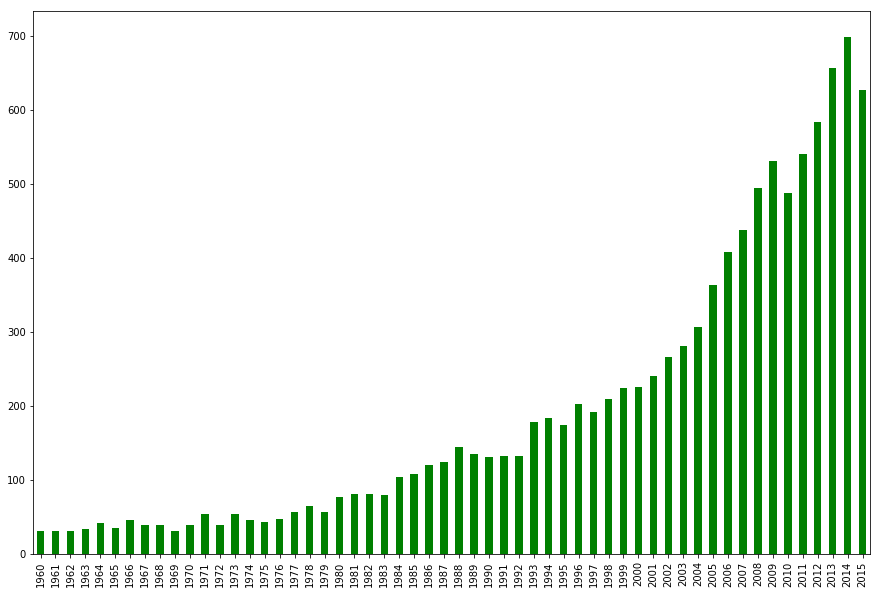

```python
df['release_year'].value_counts().sort_index().plot(kind='bar', figsize = (15,10), color = 'g');
```